# Avanced structural equation modeling

04.01.2024

This document builds on the fitting process described in the following (`1_basic_modeling.Rmd`) file.

# Load data and re-run the model

If you start from scratch, we first have to load the dataset again and refit the model. Also, let’s rescale the biomass so that they are in approximately the same range as the other variables.

```r
seabloom <- read.table(here("2_Modeling/Data_preparation/seabloom-2020-ele-dryad-data/cdr-e001-e002-output-data.csv"),
                       sep = ",", header = TRUE)

# take average across all years to avoid pseude-replication issues
seabloom <- seabloom %>% group_by(exp, field, plot, disk, yr.plowed, ntrt, nadd, other.add) %>% summarise(across(mass.above:ens.pie, mean))
```

[output not shown]

```r
# rescale AGB variable to faciliate convergence
seabloom$mass.above <- seabloom$mass.above / 100
```

## Rerun the model

First, let’s fit the pruned model that fitted the observed data well. As before, we use the robust “MLM” estimator provided by lavaan.

[figure not shown]

```r
library("lavaan")
simple <-
'mass.above ~ nadd + rich + even + disk
rich ~ nadd
even ~ nadd

rich ~~ even'

fit.simple <- sem(simple, data = seabloom, estimator = "MLM")
summary(fit.simple)
```

```
## lavaan 0.6-19 ended normally after 29 iterations
##
##   Estimator                                         ML
##   Optimization method                           NLMINB
##   Number of model parameters                        10
##
##   Number of observations                           288
##
## Model Test User Model:
##                                               Standard      Scaled
##   Test Statistic                                 2.878       2.892
##   Degrees of freedom                                 2           2
##   P-value (Chi-square)                           0.237       0.235
##   Scaling correction factor                                  0.995
##     Satorra-Bentler correction
##
## Parameter Estimates:
##
##   Standard errors                           Robust.sem
##   Information                                 Expected
##   Information saturated (h1) model          Structured
##
## Regressions:
##                    Estimate  Std.Err  z-value  P(>|z|)
##   mass.above ~
##     nadd              0.096    0.007   13.956    0.000
##     rich              0.106    0.019    5.655    0.000
##     even             -1.378    0.665   -2.072    0.038
##     disk              0.446    0.073    6.066    0.000
##   rich ~
##     nadd             -0.190    0.014  -13.573    0.000
##   even ~
##     nadd              0.006    0.001    8.503    0.000
##
## Covariances:
##                    Estimate  Std.Err  z-value  P(>|z|)
##  .rich ~~
##    .even             -0.105    0.011   -9.600    0.000
##
## Variances:
##                    Estimate  Std.Err  z-value  P(>|z|)
##    .mass.above        0.389    0.049    7.933    0.000
##    .rich              5.243    0.536    9.786    0.000
##    .even              0.006    0.001   10.754    0.000
```

# Latent and composite variables

**Latent variables** represent unmeasured variables that are represented by their indicator variables[^1] (Bollen 1989). As a consequence, a latent variable is free of random or systematic measurement errors in contrast to its indicators (Bollen 1989). They have a special role in SEM because they represent a kind of bridge between observed data and theoretical generalization (James B. Grace and Bollen 2008).

Usually, they are visualized by arrows pointing from the latent variable to the indicators (so-called “reflective” indicators (James B. Grace 2021)). This symbolizes the underlying process that generated the indicators. In other words, latent variables give rise to their indicators. Often, ellipses are used to denote a latent variable.

**Composites** are another type of variables which represent the collective effects of a set of causes on some response variable(s) (James B. Grace and Bollen 2008). In comparison to latent variables, they arise from the indicators. For this reason, they are visualized by arrows pointing from the indicators to the composite (so-called “formative” (James B. Grace 2021) or “causal indicators” (James B. Grace et al. 2010)). In that respect, they represent a collective effect (e.g., the collective effect of the abiotic environment). Since its values are determined by its causes (indicators), the error variance is specified to be 0 (James B. Grace and Bollen 2008). Thus, they are technically latent variables without variance (James B. Grace 2021). Composites are often symbolized by hexangular shapes or–the same as for latent variables–by ellipses.

**Key differences** between them are (James B. Grace and Bollen 2008):

1. The flow of causation in a latent variables is from the construct to its indicators, meaning that the indicators are driven by an underlying, unmeasured process, the latent variable. In the case of a composite variable, the flow of causation is reversed and the indicators are independent entities no matter the construct.
2. If the indicators are redundant, they likely belong to a latent variable. If the meaning of the construct changes after dropping one of the indicators, the construct likely is a composite.
3. As a latent variable represents an underlying, data-generating process, its indicators need to be correlated to each other. In the case of a composite variable, there is no assumption about the relation between the indicators. Thus, correlation among indicators are uninformative about the direction of the causal flow, but a lack of such contraindicates that the construct is a latent variable.

Carried over to our example, we measured instances of the general process “diversity” (richness, evenness etc.). Further, we summarize the abiotic condition (nutrient addition and disturbance) of a plot in a composite variable.

[figure not shown]

# Latent variable

Let’s first create a latent variable “diversity” from the three measurements of diversity (richness, evenness and ENS<sub>PIE</sub>).

Latent variable models are usually evaluated in two stages: first the fit between the latent variables and their indicators ([confirmatory factor analysis (CFA)](https://en.wikipedia.org/wiki/Confirmatory_factor_analysis)), second the full model (James B. Grace and Steiner 2021).

## Correlations between indicators

Indicators for a LV should be strongly correlated with each other. If we fail to find significant correlations based on standard tests and null hypothesis testing, we reject the hypothesis that the indicators are varying in concert and the data contradicts the claim of a latent cause (James B. Grace and Steiner 2021).

```r
cor.test(seabloom$even, seabloom$rich)
```

```
##
##  Pearson's product-moment correlation
##
## data:  seabloom$even and seabloom$rich
## t = -17.241, df = 286, p-value < 2.2e-16
## alternative hypothesis: true correlation is not equal to 0
## 95 percent confidence interval:
##  -0.7662503 -0.6521238
## sample estimates:
##        cor
## -0.7138954
```

```r
cor.test(seabloom$ens.pie, seabloom$rich)
```

```
##
##  Pearson's product-moment correlation
##
## data:  seabloom$ens.pie and seabloom$rich
## t = 36.3, df = 286, p-value < 2.2e-16
## alternative hypothesis: true correlation is not equal to 0
## 95 percent confidence interval:
##  0.8834322 0.9251138
## sample estimates:
##       cor
## 0.9064564
```

```r
cor.test(seabloom$even, seabloom$ens.pie)
```

```
##
##  Pearson's product-moment correlation
##
## data:  seabloom$even and seabloom$ens.pie
## t = -8.9763, df = 286, p-value < 2.2e-16
## alternative hypothesis: true correlation is not equal to 0
## 95 percent confidence interval:
##  -0.5543714 -0.3734909
## sample estimates:
##        cor
## -0.4688319
```

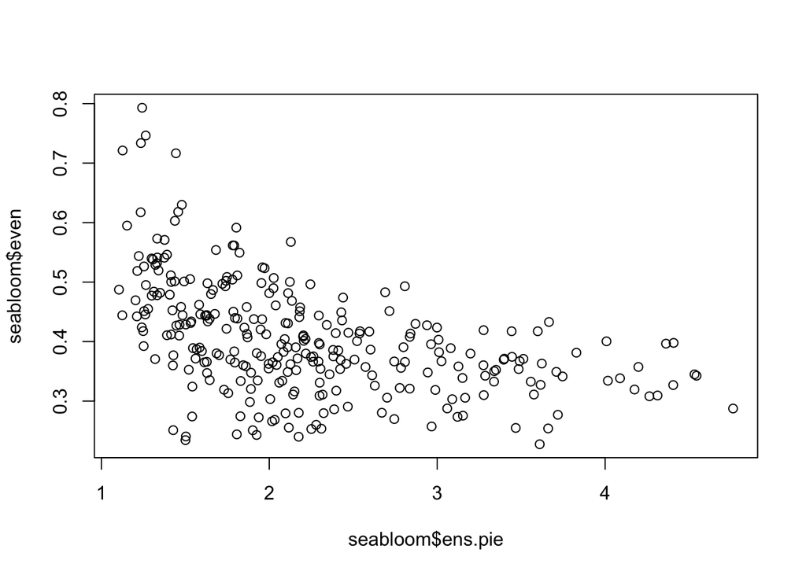

```r
## Not that surprising that there is no correlation...
plot(seabloom$ens.pie, seabloom$even)
```

To ease convergence of the algorithm, we reverse the orientation of evenness as it is negatively correlated with richness (so that absolute evenness is found at 0, while absolute unevenness is found at 1):

```r
seabloom$even.rev <- 1 - seabloom$even
cor.test(seabloom$even.rev, seabloom$rich)
```

```
##
##  Pearson's product-moment correlation
##
## data:  seabloom$even.rev and seabloom$rich
## t = 17.241, df = 286, p-value < 2.2e-16
## alternative hypothesis: true correlation is not equal to 0
## 95 percent confidence interval:
##  0.6521238 0.7662503
## sample estimates:
##       cor
## 0.7138954
```

```r
cor.test(seabloom$ens.pie, seabloom$even.rev)
```

```
##
##  Pearson's product-moment correlation
##
## data:  seabloom$ens.pie and seabloom$even.rev
## t = 8.9763, df = 286, p-value < 2.2e-16
## alternative hypothesis: true correlation is not equal to 0
## 95 percent confidence interval:
##  0.3734909 0.5543714
## sample estimates:
##       cor
## 0.4688319
```

## Confirmatory factor analysis

Let’s start with the CFA:

```r
diversity <- 'div =~ rich + even.rev + ens.pie'

fit.diversity <- cfa(diversity, data = seabloom, estimator = "MLM")
summary(fit.diversity, standardized=T, rsq=T)
```

```
## lavaan 0.6-19 ended normally after 55 iterations
##
##   Estimator                                         ML
##   Optimization method                           NLMINB
##   Number of model parameters                         6
##
##   Number of observations                           288
##
## Model Test User Model:
##                                               Standard      Scaled
##   Test Statistic                                 0.000       0.000
##   Degrees of freedom                                 0           0
##
## Parameter Estimates:
##
##   Standard errors                           Robust.sem
##   Information                                 Expected
##   Information saturated (h1) model          Structured
##
## Latent Variables:
##                    Estimate  Std.Err  z-value  P(>|z|)   Std.lv  Std.all
##   div =~
##     rich              1.000                               3.341    1.175
##     even.rev          0.017    0.002   11.193    0.000    0.057    0.608
##     ens.pie           0.185    0.010   19.465    0.000    0.620    0.772
##
## Variances:
##                    Estimate  Std.Err  z-value  P(>|z|)   Std.lv  Std.all
##    .rich             -3.075    0.456   -6.738    0.000   -3.075   -0.380
##    .even.rev          0.006    0.001    9.098    0.000    0.006    0.631
##    .ens.pie           0.261    0.027    9.649    0.000    0.261    0.405
##     div              11.162    0.898   12.434    0.000    1.000    1.000
##
## R-Square:
##                    Estimate
##     rich                 NA
##     even.rev          0.369
##     ens.pie           0.595
```

```r
varTable(fit.diversity)
```

```
##       name idx nobs    type exo user  mean   var nlev lnam
## 1     rich  10  288 numeric   0    0 6.865 8.115    0
## 2 even.rev  13  288 numeric   0    0 0.596 0.009    0
## 3  ens.pie  12  288 numeric   0    0 2.229 0.647    0
```

Parameter estimates taking improper solution, i.e. impossible values, are a sign of model misspecification. The occurrence of negative variances, as we see here, is known as “Heywood case”. Another improper solution would be correlations larger than one (Bollen 1989). Reasons for the current warning could be (i) slightly negative error estimates (what would not really be a problem), (ii) local non-identification or (iii) general misspecification (James B. Grace 2021).

Here we clearly have a problem with model mis-specification. According to (Seabloom, Borer, and Tilman (2020)), the variable ens.pie is the product of evenness and species richness. This causes the model to fail. Therefore let’s abandon the ens.pie variable for a moment and focus on a two indicator latent variable.

Latent variable models with only 2 indicators are locally non-identified because we only have one piece of information (their correlation) to estimate two path coefficients. To solve this problem, we can (a) ensure x1 and x2 have equal variances, in this case by standardizing the data. (2) When latent variables are included we must specify a fixed value for some parameter associated with the LV to achieve identification. The lavaan default is to set the loading from the LV to the first-mentioned indicator to 1.0. (3) For single-indicator LVs, the default measurement error is set to 0.0 (James B. Grace 2021).

Here we standardize the two variables and then estimate a single path coefficient by forcing a single coefficient for both indicators:

```r
seabloom$rich_std <- (mean(seabloom$rich)-seabloom$rich) / sd(seabloom$rich)
seabloom$even.rev_std <- (mean(seabloom$even.rev)-seabloom$even.rev) / sd(seabloom$even.rev)

diversity <- 'div =~ lambda*rich_std + lambda*even.rev_std'

fit.diversity <- cfa(diversity, data = seabloom, estimator = "MLM")
summary(fit.diversity, standardized=T)
```

```
## lavaan 0.6-19 ended normally after 11 iterations
##
##   Estimator                                         ML
##   Optimization method                           NLMINB
##   Number of model parameters                         3
##
##   Number of observations                           288
##
## Model Test User Model:
##                                               Standard      Scaled
##   Test Statistic                                 0.000       0.000
##   Degrees of freedom                                 0           0
##
## Parameter Estimates:
##
##   Standard errors                           Robust.sem
##   Information                                 Expected
##   Information saturated (h1) model          Structured
##
## Latent Variables:
##                    Estimate  Std.Err  z-value  P(>|z|)   Std.lv  Std.all
##   div =~
##     rch_std (lmbd)    1.000                               0.843    0.845
##     evn.rv_ (lmbd)    1.000                               0.843    0.845
##
## Variances:
##                    Estimate  Std.Err  z-value  P(>|z|)   Std.lv  Std.all
##    .rich_std          0.285    0.066    4.312    0.000    0.285    0.286
##    .even.rev_std      0.285    0.071    4.023    0.000    0.285    0.286
##     div               0.711    0.066   10.814    0.000    1.000    1.000
```

This worked, all variances are positive and we get a single coefficient for the effects of diversity on richness and evenness. As the model is just identified, we do not have a possibility to test model fit.

## Full model

Now, let’s evaluate the full model including the latent variable as well as the remaining variables.

```r
lv <- '
# Latent variable definition
diversity =~ lambda*even.rev_std + lambda*rich_std

mass.above ~ nadd + disk + diversity
diversity ~ nadd
'

fit.lv <- sem(lv, data = seabloom, estimator = "MLM")
summary(fit.lv)
```

```
## lavaan 0.6-19 ended normally after 23 iterations
##
##   Estimator                                         ML
##   Optimization method                           NLMINB
##   Number of model parameters                         8
##
##   Number of observations                           288
##
## Model Test User Model:
##                                               Standard      Scaled
##   Test Statistic                                 5.447       4.979
##   Degrees of freedom                                 4           4
##   P-value (Chi-square)                           0.244       0.290
##   Scaling correction factor                                  1.094
##     Satorra-Bentler correction
##
## Parameter Estimates:
##
##   Standard errors                           Robust.sem
##   Information                                 Expected
##   Information saturated (h1) model          Structured
##
## Latent Variables:
##                    Estimate  Std.Err  z-value  P(>|z|)
##   diversity =~
##     evn.rv_ (lmbd)    1.000
##     rch_std (lmbd)    1.000
##
## Regressions:
##                    Estimate  Std.Err  z-value  P(>|z|)
##   mass.above ~
##     nadd              0.106    0.008   13.050    0.000
##     disk              0.451    0.074    6.133    0.000
##     diversity        -0.586    0.076   -7.760    0.000
##   diversity ~
##     nadd              0.064    0.005   12.179    0.000
##
## Variances:
##                    Estimate  Std.Err  z-value  P(>|z|)
##    .even.rev_std      0.330    0.045    7.326    0.000
##    .rich_std          0.240    0.047    5.108    0.000
##    .mass.above        0.355    0.045    7.804    0.000
##    .diversity         0.392    0.040    9.740    0.000
```

The model converged and the fit is good. The coefficients suggest effects of nutrient addition on diversity. However, we would expect a negative effect of nutrient addition on diversity, while the effect is positive. The opposite expectation would hold for diversity on AGB, but here we see a negative effect. Can you explain why this is the case?

Right, it has to do with reversing the direction of the evenness effect. As both richness and reversed evenness influence AGB, the meaning of the latent diversity effect is reversed. We can see this when we fit a model that just contains the ens.pie variable:

```r
lv <- '
mass.above ~ nadd + disk + ens.pie
ens.pie ~ nadd
'

fit.lv <- sem(lv, data = seabloom, estimator = "MLM")
summary(fit.lv)
```

```
## lavaan 0.6-19 ended normally after 1 iteration
##
##   Estimator                                         ML
##   Optimization method                           NLMINB
##   Number of model parameters                         6
##
##   Number of observations                           288
##
## Model Test User Model:
##                                               Standard      Scaled
##   Test Statistic                                 0.110       0.110
##   Degrees of freedom                                 1           1
##   P-value (Chi-square)                           0.740       0.740
##   Scaling correction factor                                  1.000
##     Satorra-Bentler correction
##
## Parameter Estimates:
##
##   Standard errors                           Robust.sem
##   Information                                 Expected
##   Information saturated (h1) model          Structured
##
## Regressions:
##                    Estimate  Std.Err  z-value  P(>|z|)
##   mass.above ~
##     nadd              0.089    0.006   15.010    0.000
##     disk              0.481    0.074    6.499    0.000
##     ens.pie           0.449    0.048    9.403    0.000
##   ens.pie ~
##     nadd             -0.047    0.004  -11.498    0.000
##
## Variances:
##                    Estimate  Std.Err  z-value  P(>|z|)
##    .mass.above        0.394    0.059    6.732    0.000
##    .ens.pie           0.470    0.043   10.959    0.000
```

As you can see, now the joint effect of evenness and richness is negatively influenced by nutrient addition and AGB is positivelyaffected by diversity. The model is also fitting the data pretty well.

# Composite variable

Composite variables are another type of variable that make the SEM framework very flexible. As described above, composite variables specify the influence of collections of other variables. In comparison to latent variables, they arise from the indicators. They are hence visualized by arrows pointing from the indicators to the composite (formative or causal indicators). Composite variables are a great means to ease the interpretation of multiple indicators at once.

## Landuse composite

```r
comp <- '
comp.landuse <~ 1 * disk + nadd

rich ~  comp.landuse
even ~  comp.landuse
mass.above ~ comp.landuse + rich + even

rich ~~ even'

fit.comp <- sem(comp, data = seabloom)
summary(fit.comp, standardized=T)
```

```
## lavaan 0.6-19 ended normally after 44 iterations
##
##   Estimator                                         ML
##   Optimization method                           NLMINB
##   Number of model parameters                        10
##
##   Number of observations                           288
##
## Model Test User Model:
##
##   Test statistic                                16.903
##   Degrees of freedom                                 2
##   P-value (Chi-square)                           0.000
##
## Parameter Estimates:
##
##   Standard errors                             Standard
##   Information                                 Expected
##   Information saturated (h1) model          Structured
##
## Composites:
##                    Estimate  Std.Err  z-value  P(>|z|)   Std.lv  Std.all
##   comp.landuse <~
##     disk              1.000                               0.352    0.176
##     nadd              0.316    0.067    4.702    0.000    0.111    0.984
##
## Regressions:
##                    Estimate  Std.Err  z-value  P(>|z|)   Std.lv  Std.all
##   rich ~
##     comp.landuse     -0.571    0.127   -4.488    0.000   -1.624   -0.571
##   even ~
##     comp.landuse      0.018    0.004    4.419    0.000    0.050    0.534
##   mass.above ~
##     comp.landuse      0.312    0.066    4.705    0.000    0.888    0.929
##     rich              0.112    0.020    5.712    0.000    0.112    0.333
##     even             -1.383    0.573   -2.414    0.016   -1.383   -0.137
##
## Covariances:
##                    Estimate  Std.Err  z-value  P(>|z|)   Std.lv  Std.all
##  .rich ~~
##    .even             -0.110    0.013   -8.617    0.000   -0.110   -0.589
##
## Variances:
##                    Estimate  Std.Err  z-value  P(>|z|)   Std.lv  Std.all
##    .rich              5.450    0.454   12.000    0.000    5.450    0.674
##    .even              0.006    0.001   12.000    0.000    0.006    0.715
##    .mass.above        0.393    0.033   12.000    0.000    0.393    0.431
##     comp.landuse      0.000                               0.000    0.000
```

### Manually compute composite

Sometimes `lavaan` struggles to fit models with composites. In such cases, the composites can be first calculated manually and then incorporated into the model as a regular variable (James B. Grace 2021).

First, we specify and fit a model containing only the indicators and the response.

```r
comp.man <- 'mass.above ~ disk + nadd'
fit.comp.man <- sem(comp.man, data = seabloom)
summary(fit.comp.man)
```

```
## lavaan 0.6-19 ended normally after 1 iteration
##
##   Estimator                                         ML
##   Optimization method                           NLMINB
##   Number of model parameters                         3
##
##   Number of observations                           288
##
## Model Test User Model:
##
##   Test statistic                                 0.000
##   Degrees of freedom                                 0
##
## Parameter Estimates:
##
##   Standard errors                             Standard
##   Information                                 Expected
##   Information saturated (h1) model          Structured
##
## Regressions:
##                    Estimate  Std.Err  z-value  P(>|z|)
##   mass.above ~
##     disk              0.493    0.082    5.981    0.000
##     nadd              0.068    0.005   14.627    0.000
##
## Variances:
##                    Estimate  Std.Err  z-value  P(>|z|)
##    .mass.above        0.489    0.041   12.000    0.000
```

Then, we compute the composite scores by taking the sum of all indicator variables multiplied by their estimates.

```r
seabloom$landuse <- lavInspect(fit.comp.man, what = "est")$beta[1, 2] * seabloom$disk +
  lavInspect(fit.comp.man, what = "est")$beta[1, 3] * seabloom$nadd
```

Fitting this newly calculated variable `landuse` to the response `mass.above`…

```r
comp.man2 <- 'mass.above ~ landuse'
fit.comp.man2 <- sem(comp.man2, data = seabloom)
```

… yields the same standardized coefficient and R<sup>2</sup> for `mass.above` as above.

```r
lavInspect(fit.comp.man, "std.nox")$psi[1, 1]
```

```
## [1] 0.5355781
```

```r
lavInspect(fit.comp.man2, "std.nox")$psi[1, 1]
```

```
## [1] 0.5355781
```

```r
lavInspect(fit.comp.man, "rsquare")
```

```
## mass.above
##      0.464
```

```r
lavInspect(fit.comp.man2, "rsquare")
```

```
## mass.above
##      0.464
```

Finally, we can integrate the composite `landuse` into the `simple` model from before.

```r
comp <- '
rich ~  landuse
even ~ landuse

mass.above ~ landuse + rich + even

rich ~~ even'

fit.comp <- sem(comp, data = seabloom)
summary(fit.comp, standardized=T)
```

```
## lavaan 0.6-19 ended normally after 16 iterations
##
##   Estimator                                         ML
##   Optimization method                           NLMINB
##   Number of model parameters                         9
##
##   Number of observations                           288
##
## Model Test User Model:
##
##   Test statistic                                 0.000
##   Degrees of freedom                                 0
##
## Parameter Estimates:
##
##   Standard errors                             Standard
##   Information                                 Expected
##   Information saturated (h1) model          Structured
##
## Regressions:
##                    Estimate  Std.Err  z-value  P(>|z|)   Std.lv  Std.all
##   rich ~
##     landuse          -2.277    0.220  -10.371    0.000   -2.277   -0.521
##   even ~
##     landuse           0.072    0.007    9.762    0.000    0.072    0.499
##   mass.above ~
##     landuse           1.300    0.069   18.939    0.000    1.300    0.886
##     rich              0.091    0.019    4.693    0.000    0.091    0.272
##     even             -1.279    0.577   -2.216    0.027   -1.279   -0.126
##
## Covariances:
##                    Estimate  Std.Err  z-value  P(>|z|)   Std.lv  Std.all
##  .rich ~~
##    .even             -0.122    0.014   -8.876    0.000   -0.122   -0.614
##
## Variances:
##                    Estimate  Std.Err  z-value  P(>|z|)   Std.lv  Std.all
##    .rich              5.888    0.491   12.000    0.000    5.888    0.728
##    .even              0.007    0.001   12.000    0.000    0.007    0.751
##    .mass.above        0.400    0.033   12.000    0.000    0.400    0.439
```

When you compare the estimates of the composites fitted automatically or manually, you see that they are very close, as is expected.

## Interactions

In nature, things often are contingent on each other. For instance, the effect of nutrients on plant growth, may depend on how disturbed the environment is. Such a behaviour is called an interaction, which indicates that the effect of the two main effects are different when combined.

[figure not shown]

First, let’s visually inspect the hypothesized interaction between the effect of disturbance on above-ground biomass and the amount of nutrients.

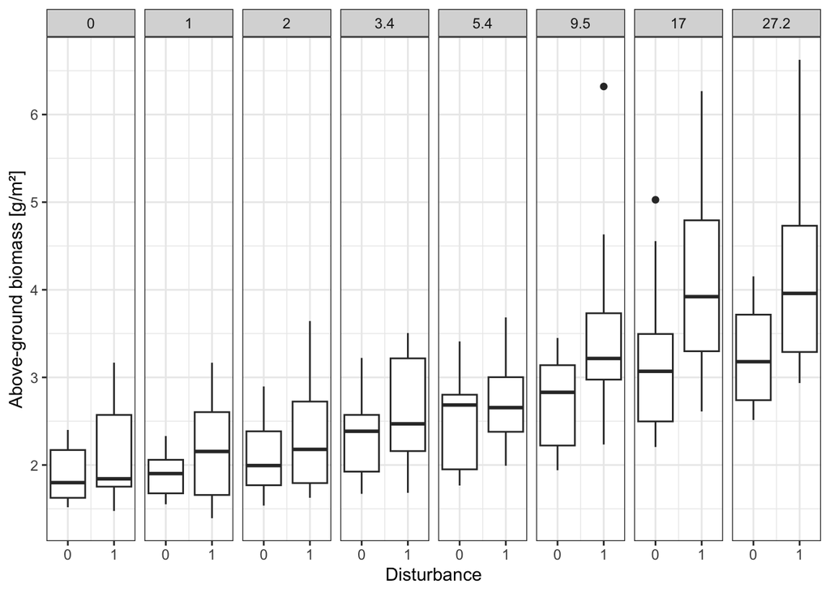

```r
library("ggplot2")
theme_set(theme_bw())


ggplot(aes(disk, mass.above, group = disk), data = seabloom) +
  geom_boxplot() +
  facet_grid( ~ nadd) +
  scale_x_continuous(breaks = c(0, 1)) +
  xlab("Disturbance") +
  ylab("Above-ground biomass [g/m²]")
```

It seems that the higher the amount of added nutrients, the higher the gap in above-ground biomass between the disturbed and undisturbed plots.

### Modeling the interaction

[figure not shown]

In regression, the interaction is represented by a coefficient that estimates the effect of the product of the two predictors. Let’s create this new variable and call it diskxnadd.

```r
seabloom$diskxnadd <- seabloom$disk * seabloom$nadd

int <- 'mass.above ~ disk + nadd + diskxnadd'
fit.int <- sem(int, data = seabloom)
summary(fit.int)
```

```
## lavaan 0.6-19 ended normally after 1 iteration
##
##   Estimator                                         ML
##   Optimization method                           NLMINB
##   Number of model parameters                         4
##
##   Number of observations                           288
##
## Model Test User Model:
##
##   Test statistic                                 0.000
##   Degrees of freedom                                 0
##
## Parameter Estimates:
##
##   Standard errors                             Standard
##   Information                                 Expected
##   Information saturated (h1) model          Structured
##
## Regressions:
##                    Estimate  Std.Err  z-value  P(>|z|)
##   mass.above ~
##     disk              0.228    0.110    2.076    0.038
##     nadd              0.052    0.006    8.053    0.000
##     diskxnadd         0.032    0.009    3.556    0.000
##
## Variances:
##                    Estimate  Std.Err  z-value  P(>|z|)
##    .mass.above        0.468    0.039   12.000    0.000
```

The results show a significant effect of both variables and their interaction.

Next, we model them as a composite:

```r
compint <-
'comp.int <~ 1 * disk + nadd + diskxnadd
mass.above ~ comp.int'

fit.compint <- sem(compint, data = seabloom)
summary(fit.compint, standardized = TRUE)
```

```
## lavaan 0.6-19 ended normally after 27 iterations
##
##   Estimator                                         ML
##   Optimization method                           NLMINB
##   Number of model parameters                         4
##
##   Number of observations                           288
##
## Model Test User Model:
##
##   Test statistic                                 0.000
##   Degrees of freedom                                 0
##
## Parameter Estimates:
##
##   Standard errors                             Standard
##   Information                                 Expected
##   Information saturated (h1) model          Structured
##
## Composites:
##                    Estimate  Std.Err  z-value  P(>|z|)   Std.lv  Std.all
##   comp.int <~
##     disk              1.000                               0.342    0.171
##     nadd              0.227    0.099    2.294    0.022    0.078    0.689
##     diskxnadd         0.142    0.100    1.421    0.155    0.049    0.363
##
## Regressions:
##                    Estimate  Std.Err  z-value  P(>|z|)   Std.lv  Std.all
##   mass.above ~
##     comp.int          0.228    0.110    2.076    0.038    0.667    0.698
##
## Variances:
##                    Estimate  Std.Err  z-value  P(>|z|)   Std.lv  Std.all
##    .mass.above        0.468    0.039   12.000    0.000    0.468    0.513
##     comp.int          0.000                               0.000    0.000
```

The combined effect of the predictors is the `std.all` value for the regression (0.698).

### Full model

```r
int.full <-
'comp.int <~ 1 * disk + nadd + diskxnadd

mass.above ~ comp.int + rich + even
rich ~ nadd
even ~ nadd

rich ~~ even'

fit.int.full <- sem(int.full, data = seabloom)
summary(fit.int.full, fit.measures = TRUE, standardized = TRUE, rsq = TRUE)
```

```
## lavaan 0.6-19 ended normally after 87 iterations
##
##   Estimator                                         ML
##   Optimization method                           NLMINB
##   Number of model parameters                        11
##
##   Number of observations                           288
##
## Model Test User Model:
##
##   Test statistic                                13.640
##   Degrees of freedom                                 4
##   P-value (Chi-square)                           0.009
##
## Model Test Baseline Model:
##
##   Test statistic                               630.861
##   Degrees of freedom                                12
##   P-value                                        0.000
##
## User Model versus Baseline Model:
##
##   Comparative Fit Index (CFI)                    0.984
##   Tucker-Lewis Index (TLI)                       0.953
##
## Loglikelihood and Information Criteria:
##
##   Loglikelihood user model (H0)               -525.332
##   Loglikelihood unrestricted model (H1)       -518.512
##
##   Akaike (AIC)                                1072.664
##   Bayesian (BIC)                              1112.957
##   Sample-size adjusted Bayesian (SABIC)       1078.075
##
## Root Mean Square Error of Approximation:
##
##   RMSEA                                          0.091
##   90 Percent confidence interval - lower         0.041
##   90 Percent confidence interval - upper         0.147
##   P-value H_0: RMSEA <= 0.050                    0.081
```

[output cut: 32 more lines]

```
##  .rich ~~
##    .even             -0.105    0.012   -8.503    0.000   -0.105   -0.579
##
## Variances:
##                    Estimate  Std.Err  z-value  P(>|z|)   Std.lv  Std.all
##    .mass.above        0.353    0.029   12.000    0.000    0.353    0.383
##    .rich              5.243    0.437   12.000    0.000    5.243    0.648
##    .even              0.006    0.001   12.000    0.000    0.006    0.703
##     comp.int          0.000                               0.000    0.000
##
## R-Square:
##                    Estimate
##     mass.above        0.617
##     rich              0.352
##     even              0.297
```

Not the greatest fit in terms of $p$-value (0.01), but really fine in terms of CFI (0.984).

## Multigroup fitting

Another way to incorporate interactions is to fit SEMs where coefficients can vary among groups. Lavaan offers the “group” argument to specify for which groups coefficients should be estimated. Importantly, groups have to be of categorical nature. For our dataset, the application of the disturbance (“yes” vs “no”) is categorical. So let’s fit the SEM to the two disturbance regimes:

```r
int.mg <-
'mass.above ~ rich + even
rich ~ nadd
even ~ nadd

rich ~~ even'

fit.int.mg <- sem(int.mg, group = "disk", data = seabloom)
summary(fit.int.mg, standardized = TRUE, rsq = TRUE)
```

```
## lavaan 0.6-19 ended normally after 79 iterations
##
##   Estimator                                         ML
##   Optimization method                           NLMINB
##   Number of model parameters                        22
##
##   Number of observations per group:
##     0                                              144
##     1                                              144
##
## Model Test User Model:
##
##   Test statistic                               233.666
##   Degrees of freedom                                 2
##   P-value (Chi-square)                           0.000
##   Test statistic for each group:
##     0                                           86.347
##     1                                          147.319
##
## Parameter Estimates:
##
##   Standard errors                             Standard
##   Information                                 Expected
##   Information saturated (h1) model          Structured
##
##
## Group 1 [0]:
##
## Regressions:
##                    Estimate  Std.Err  z-value  P(>|z|)   Std.lv  Std.all
##   mass.above ~
##     rich             -0.081    0.034   -2.364    0.018   -0.081   -0.267
##     even              0.243    1.033    0.235    0.814    0.243    0.027
##   rich ~
##     nadd             -0.168    0.016  -10.587    0.000   -0.168   -0.662
##   even ~
##     nadd              0.004    0.001    6.690    0.000    0.004    0.487
##
## Covariances:
##                    Estimate  Std.Err  z-value  P(>|z|)   Std.lv  Std.all
```

[output cut: 41 more lines]

```
##    .mass.above        2.458    0.719    3.417    0.001    2.458    2.210
##    .rich              8.810    0.310   28.413    0.000    8.810    2.655
##    .even              0.341    0.010   34.045    0.000    0.341    3.088
##
## Variances:
##                    Estimate  Std.Err  z-value  P(>|z|)   Std.lv  Std.all
##    .mass.above        1.226    0.144    8.485    0.000    1.226    0.991
##    .rich              7.470    0.880    8.485    0.000    7.470    0.678
##    .even              0.008    0.001    8.485    0.000    0.008    0.639
##
## R-Square:
##                    Estimate
##     mass.above        0.009
##     rich              0.322
##     even              0.361
```

The default option is to let all coefficients vary between groups, but have the same structure of direct and indirect effects. Let’s visualize the estimated coefficients:

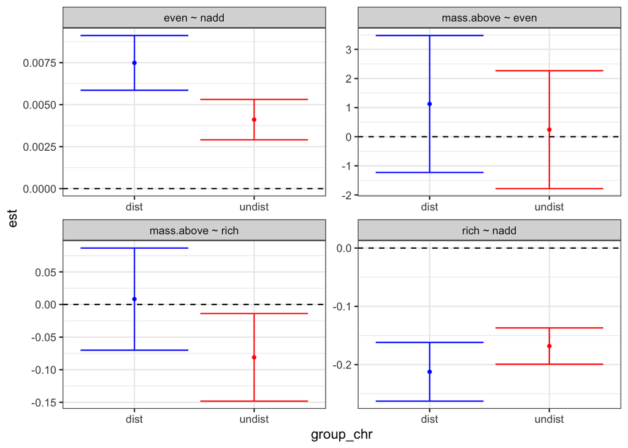

```r
fit_tab <- (summary(fit.int.mg, standardized = TRUE, rsq = TRUE))$pe
fit_tab$term <- paste0(fit_tab$lhs, " ", fit_tab$op, " ", fit_tab$rhs)
fit_tab$group_chr <- ifelse(fit_tab$group == 1, "undist",
                            ifelse(fit_tab$group == 2, "dist", NA))

ggplot(data=subset(fit_tab, op == "~"), aes(y=est, x=group_chr, colour=group_chr)) +
  geom_point(size=1) + geom_errorbar(aes(ymin = est-se*1.96, ymax = est+se*1.96)) +
  facet_wrap(~term, scales="free") +
  scale_colour_manual(values = c("blue",  "red")) +
  geom_hline(aes(yintercept = 0), colour = "black", linetype = "dashed") +
  guides(colour="none") +
  theme_bw()
```

Each facet grid shows a path and the estimated coefficients, one for disturbed (in blue) and one for the undisturbed plots (in red).

To test equality constraints, such as same means of coefficients among groups, lavaan offers the “group.equal” argument:

```r
group.equal=c(
"intercepts",
"means",
"regressions",
"residuals",
"residual.covariances")

#fit.int.mg <- sem(int.mg, group = "disk", group.equal = c("regressions"), data = seabloom)
```

Furthermore, we can test equality constraints by labeling parameters. To do so, we provide namees for the path coefficients that we want to be equal for both groups (e.g. “b1”), whereas path coefficients that we want to vary between groups have different names (e.g., “b4a” and “b4b”).

```r
int.mg.constrain <-
'mass.above ~  c("b1", "b1") * rich + c("b2", "b2") * even
rich ~ c("b4a", "b4b") * nadd
even ~ c("b6a", "b6b") *  nadd

rich ~~ even'

fit.int.mg.constrain <- sem(int.mg.constrain, group = "disk", data = seabloom)
summary(fit.int.mg.constrain, standardized = TRUE, rsq = TRUE)
```

```
## lavaan 0.6-19 ended normally after 77 iterations
##
##   Estimator                                         ML
##   Optimization method                           NLMINB
##   Number of model parameters                        22
##   Number of equality constraints                     2
##
##   Number of observations per group:
##     0                                              144
##     1                                              144
##
## Model Test User Model:
##
##   Test statistic                               237.391
##   Degrees of freedom                                 4
##   P-value (Chi-square)                           0.000
##   Test statistic for each group:
##     0                                           87.939
##     1                                          149.453
##
## Parameter Estimates:
##
##   Standard errors                             Standard
##   Information                                 Expected
##   Information saturated (h1) model          Structured
##
##
## Group 1 [0]:
##
## Regressions:
##                    Estimate  Std.Err  z-value  P(>|z|)   Std.lv  Std.all
##   mass.above ~
##     rich      (b1)   -0.043    0.026   -1.647    0.100   -0.043   -0.145
##     even      (b2)    0.604    0.788    0.767    0.443    0.604    0.067
##   rich ~
##     nadd     (b4a)   -0.168    0.016  -10.587    0.000   -0.168   -0.662
##   even ~
##     nadd     (b6a)    0.004    0.001    6.690    0.000    0.004    0.487
##
## Covariances:
```

[output cut: 42 more lines]

```
##    .mass.above        3.031    0.477    6.359    0.000    3.031    2.676
##    .rich              8.810    0.310   28.413    0.000    8.810    2.655
##    .even              0.341    0.010   34.045    0.000    0.341    3.088
##
## Variances:
##                    Estimate  Std.Err  z-value  P(>|z|)   Std.lv  Std.all
##    .mass.above        1.244    0.147    8.485    0.000    1.244    0.970
##    .rich              7.470    0.880    8.485    0.000    7.470    0.678
##    .even              0.008    0.001    8.485    0.000    0.008    0.639
##
## R-Square:
##                    Estimate
##     mass.above        0.030
##     rich              0.322
##     even              0.361
```

Let’s visualize again the coefficients to see the effect:

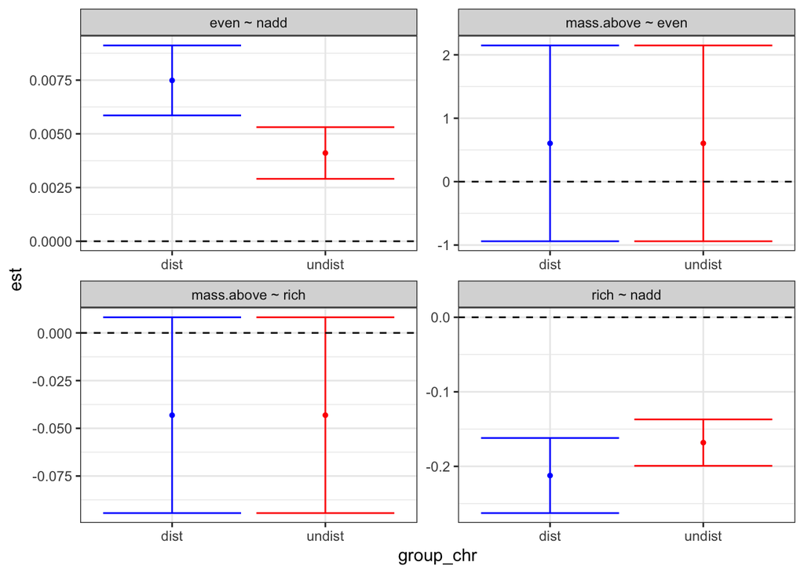

```r
fit_tab <- (summary(fit.int.mg.constrain, standardized = TRUE, rsq = TRUE))$pe
fit_tab$term <- paste0(fit_tab$lhs, " ", fit_tab$op, " ", fit_tab$rhs)
fit_tab$group_chr <- ifelse(fit_tab$group == 1, "undist",
                            ifelse(fit_tab$group == 2, "dist", NA))

ggplot(data=subset(fit_tab, op == "~"), aes(y=est, x=group_chr, colour=group_chr)) +
  geom_point(size=1) + geom_errorbar(aes(ymin = est-se*1.96, ymax = est+se*1.96)) +
  facet_wrap(~term, scales="free") +
  scale_colour_manual(values = c("blue",  "red")) +
  geom_hline(aes(yintercept = 0), colour = "black", linetype = "dashed") +
  guides(colour="none") +
  theme_bw()
```

```r
library(AICcmodavg)
aictab(list(fit.int.mg, fit.int.mg.constrain))
```

```
##
## Model selection based on AICc:
##
##       K    AICc Delta_AICc AICcWt Cum.Wt      LL
## Mod2 20 1247.26       0.00   0.71   0.71 -600.21
## Mod1 22 1249.06       1.81   0.29   1.00 -598.35
```

# References

Bollen, Kenneth A. 1989. *Structural Equations with Latent Variables*. USA: John Wiley & Sons.

Grace, James B. 2021. “Quantitative Analysis Using Structural Equation Modeling.” 2021. https://www.usgs.gov/centers/wetland-and-aquatic-research-center/science/quantitative-analysis-using-structural-equation?qt-science_center_objects=0#qt-science_center_objects.

Grace, James B., T. Michael Anderson, Han Olff, and Samuel M. Scheiner. 2010. “On the Specification of Structural Equation Models for Ecological Systems.” *Ecological Monographs* 80 (1): 67–87. http://www.jstor.org/stable/27806874.

Grace, James B, and Kenneth A. Bollen. 2008. “Representing General Theoretical Concepts in Structural Equation Models: The Role of Composite Variables.” *Environmental and Ecological Statistics* 15: 191–213. https://doi.org/https://doi.org/10.1007/s10651-007-0047-7.

Grace, James B, and Magdalena Steiner. 2021. “A Protocol for Modelling Generalised Biological Responses Using Latent Variables in Structural Equation Models.” *One Ecosystem* 6: e67320. https://doi.org/10.3897/oneeco.6.e67320.

Seabloom, Eric W., Elizabeth T. Borer, and David Tilman. 2020. “Grassland Ecosystem Recovery After Soil Disturbance Depends on Nutrient Supply Rate.” *Ecology Letters* 23 (12): 1756–65. https://doi.org/https://doi.org/10.1111/ele.13591.

[^1]: Indicator variables are observed/manifest variables that are linked to either a latent or composite variable.